# GenEst Command Line Example

Juniper L. Simonis

This vignette walks through an example of **GenEst** at the command line and was constructed using **GenEst** version 0.0.3.12 on 2018-04-14.

## Installation

To obtain the most recent version of **GenEst**, use the **devtools** package to download it from GitHub:

```r
install.packages("devtools")
devtools::install_github("ddalthorp/GenEst")
```

## Data

For this vignette, we will be using a completely mock dataset provided with the **GenEst** package, which contains Searcher Efficiency, Carcass Persistence, Search Schedule, Density Weighted Proportion, and Carcass Observation Data.

```r
data(mockData)
names(mockData)
```

```
#> [1] "SearcherEfficiencyData"        "CarcassPersistenceData"
#> [3] "SearchScheduleData"            "DensityWeightedProportionData"
#> [5] "CarcassObservationData"
```

To see the raw `.csv` versions of the data files, find the **GenEst** package folder on your computer (it should be located with all of your other R packages) and then browse to the `inst/extdata/mockData` subfolder.

## Searcher Efficiency

### Single Searcher Efficiency Model

The central function for searcher efficiency analyses is `pkm`, which conducts a singular searcher efficiency analysis (*i.e.*, a singular set of `p` and `k` formulae and a singular size classification of carcasses). As a first example, we will ignore the size category and use intercept-only models for both `p` and `k`:

```r
dataSE <- mockData$SearcherEfficiencyData
pkModel <- pkm(formula_p = p ~ 1, formula_k = k ~ 1, data = dataSE)
```

Here, we have taken advantage of `pkm`’s default behavior of selecting observation columns (see `?pkm` for details).

```r
head(dataSE)
```

```
#>   ID Visibility HabitatType Season Size Search1 Search2 Search3 Search4
#> 1  1          L         HT1     SF    S       1      NA      NA      NA
#> 2  2          L         HT1     SF    S       1      NA      NA      NA
#> 3  3          L         HT1     WS    S       0       0       0       0
#> 4  4          L         HT1     WS    S       1      NA      NA      NA
#> 5  5          L         HT1     WS    S       0       1      NA      NA
#> 6  6          L         HT1     SF    S       1      NA      NA      NA
```

If we wanted to explicitly control the observations, we would use the `obsCol` argument:

```r
pkModel <- pkm(formula_p = p ~ 1, formula_k = k ~ 1, data = dataSE,
             obsCol = c("Search1", "Search2", "Search3", "Search4")
           )
```

Note that the search observations must be entered in order such that no carcasses have non-detected observations (*i.e.*, `0`) after detected observations (*i.e.*, `1`). Further, no carcasses can be detected more than once.

If successfully fit, a `pkm` model output contains a number of elements, some printed automatically:

```r
pkModel
```

```
#> $call
#> pkm(formula_p = p ~ 1, formula_k = k ~ 1, data = dataSE, obsCol = c("Search1",
#>     "Search2", "Search3", "Search4"))
#>
#> $formula_p
#> p ~ 1
#>
#> $formula_k
#> k ~ 1
#>
#> $predictors
#> character(0)
#>
#> $AICc
#> [1] 1144.998
#>
#> $convergence
#> [1] 0
#>
#> $cellwiseTable
#>   cell p_median p_lower p_upper k_median k_lower k_upper
#> 1  all  0.56845 0.53166  0.6045  0.59906 0.54296 0.65268
```

and others available upon request (using `$` as `pkm` is an S3 class):

```r
names(pkModel)
```

```
#>  [1] "call"          "formula_p"     "formula_k"     "predictors"
#>  [5] "predictors_p"  "predictors_k"  "AIC"           "AICc"
#>  [9] "convergence"   "varbeta"       "cellMM_p"      "cellMM_k"
#> [13] "nbeta_p"       "nbeta_k"       "betahat_p"     "betahat_k"
#> [17] "cells"         "ncell"         "cellwiseTable" "observations"
#> [21] "carcCells"     "CL"
```

```r
pkModel$cells
```

```
#>   group CellNames
#> 1   all       all
```

The `plot` function has been defined for `pkm` objects, such that one can simply run

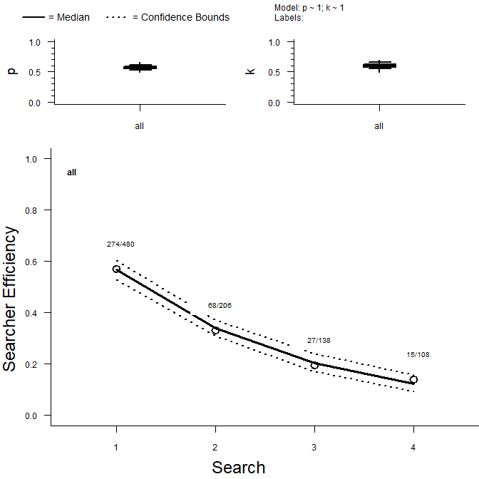

```r
plot(pkModel)
```

to visualize the model’s output.

You can generate random draws of the `p` and `k` parameters for each cell grouping (in `pkModel` there are no predictors, so there is one cell grouping called “all”) using the `rpk` function which, like other `r*` functions in **R** (*i.e.*, `rnorm`) takes the number of random draws (`n`) as the first argument:

```r
rpk(n = 10, pkModel)
```

```
#> $all
#>               p         k
#>  [1,] 0.5601628 0.5392728
#>  [2,] 0.5999821 0.6073095
#>  [3,] 0.5633458 0.6221270
#>  [4,] 0.5769051 0.5548144
#>  [5,] 0.5236103 0.6038052
#>  [6,] 0.5676538 0.5654118
#>  [7,] 0.5791335 0.5862906
#>  [8,] 0.5789107 0.6365192
#>  [9,] 0.5599069 0.5733311
#> [10,] 0.5635451 0.6443420
```

You can complicate the `p` and `k` formulae independently

```r
pkm(formula_p = p ~ Visibility, formula_k = k ~ HabitatType, data = dataSE,
  obsCol = c("Search1", "Search2", "Search3", "Search4")
)
```

```
#> $call
#> pkm(formula_p = p ~ Visibility, formula_k = k ~ HabitatType,
#>     data = dataSE, obsCol = c("Search1", "Search2", "Search3",
#>         "Search4"))
#>
#> $formula_p
#> p ~ Visibility
#>
#> $formula_k
#> k ~ HabitatType
#>
#> $predictors
#> [1] "Visibility"  "HabitatType"
#>
#> $AICc
#> [1] 1149.666
#>
#> $convergence
#> [1] 0
#>
#> $cellwiseTable
#>    cell p_median p_lower p_upper k_median k_lower k_upper
#> 1 H.HT1  0.56403 0.50325 0.62295  0.56018 0.48176 0.63570
#> 2 L.HT1  0.57788 0.51633 0.63710  0.56018 0.48176 0.63570
#> 3 M.HT1  0.56348 0.50479 0.62044  0.56018 0.48176 0.63570
#> 4 H.HT2  0.56403 0.50325 0.62295  0.63125 0.55665 0.70007
#> 5 L.HT2  0.57788 0.51633 0.63710  0.63125 0.55665 0.70007
#> 6 M.HT2  0.56348 0.50479 0.62044  0.63125 0.55665 0.70007
```

And you can fix `k` at a nominal value between 0 and 1 (inclusive) using the `kFixed` argument

```r
pkm(formula_p = p ~ Visibility, kFixed = 0.7, data = dataSE,
  obsCol = c("Search1", "Search2", "Search3", "Search4")
)
```

[output not shown]

### Set of Searcher Efficiency Models

The function `pkmSet` provides a simple wrapper on `pkm` that facilitates analyzing a set of `pkm` models defined as all allowable models simpler than, and including, the provided model formulae (where “allowable” means that any interaction terms have all component terms included in the model).

Consider the following model set analysis, where visibility and habitat type are included in the `p` formula but only habitat type is in the `k` formula, which generates a set of 10 models:

```r
pkmModSet <- pkmSet(formula_p = p ~ Visibility*HabitatType,
               formula_k = k ~ HabitatType, data = dataSE,
               obsCol = c("Search1", "Search2", "Search3", "Search4")
             )
names(pkmModSet)
```

```
#>  [1] "p ~ Visibility * HabitatType; k ~ HabitatType"
#>  [2] "p ~ Visibility + HabitatType; k ~ HabitatType"
#>  [3] "p ~ HabitatType; k ~ HabitatType"
#>  [4] "p ~ Visibility; k ~ HabitatType"
#>  [5] "p ~ 1; k ~ HabitatType"
#>  [6] "p ~ Visibility * HabitatType; k ~ 1"
#>  [7] "p ~ Visibility + HabitatType; k ~ 1"
#>  [8] "p ~ HabitatType; k ~ 1"
#>  [9] "p ~ Visibility; k ~ 1"
#> [10] "p ~ 1; k ~ 1"
```

The `plot` function is defined for the `pkmSet` class, and by default, creates a new plot window on command for each sub-model. If we want to only plot a specific single (or subset) of models from the full set, we can utilize the `specificModel` argument:

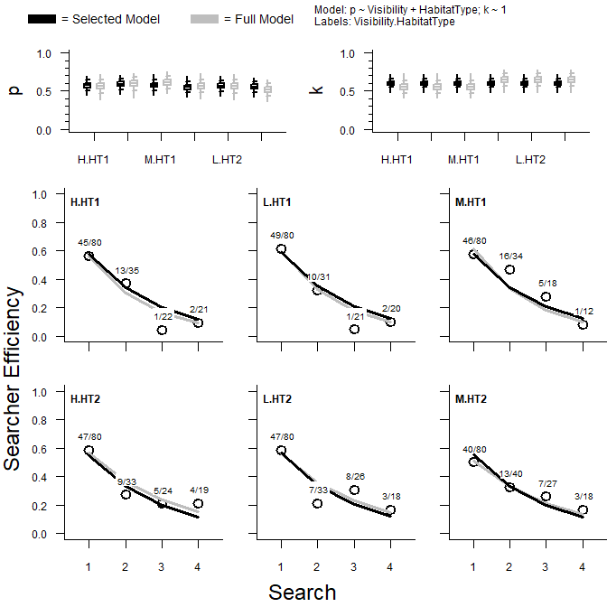

```r
plot(pkmModSet, specificModel = "p ~ Visibility + HabitatType; k ~ 1")
```

The resulting model outputs can be compared in an AICc table

```r
pkmSetAICcTab(pkmModSet)
```

```
#>                       p formula       k formula     AICc Delta AICc
#> 10                        p ~ 1           k ~ 1 1144.998      0.000
#> 5                         p ~ 1 k ~ HabitatType 1145.697      0.699
#> 3               p ~ HabitatType k ~ HabitatType 1146.570      1.572
#> 8               p ~ HabitatType           k ~ 1 1146.756      1.758
#> 9                p ~ Visibility           k ~ 1 1148.959      3.961
#> 4                p ~ Visibility k ~ HabitatType 1149.666      4.668
#> 2  p ~ Visibility + HabitatType k ~ HabitatType 1150.546      5.548
#> 7  p ~ Visibility + HabitatType           k ~ 1 1150.731      5.733
#> 1  p ~ Visibility * HabitatType k ~ HabitatType 1153.449      8.451
#> 6  p ~ Visibility * HabitatType           k ~ 1 1153.490      8.492
```

### Multiple Sizes of Animals and Sets of Searcher Efficiency Models

Often, carcasses are grouped in multiple size classes, and we are interested in analyzing a set of models separately for each size class. To do so, we use the `pkmSetSize` function, which is a wrapper on `pkmSet` that runs the subfunction for each unique size class in the column identified by the `sizeclassCol` argument:

```r
pkmModSetSize <- pkmSetSize(formula_p = p ~ Visibility*HabitatType,
                   formula_k = k ~ HabitatType, data = dataSE,
                   obsCol = c("Search1", "Search2", "Search3", "Search4"),
                   sizeclassCol = "Size"
                 )
```

The output from `pkmSetSize` is a list where each element corresponds to a different unique size class, and contains the associated `pkmSet`object, which itself is a list of `pkm` outputs:

```r
names(pkmModSetSize)
```

```
#> [1] "S"  "L"  "M"  "XL"
```

```r
names(pkmModSetSize[[1]])
```

```
#>  [1] "p ~ Visibility * HabitatType; k ~ HabitatType"
#>  [2] "p ~ Visibility + HabitatType; k ~ HabitatType"
#>  [3] "p ~ HabitatType; k ~ HabitatType"
#>  [4] "p ~ Visibility; k ~ HabitatType"
#>  [5] "p ~ 1; k ~ HabitatType"
#>  [6] "p ~ Visibility * HabitatType; k ~ 1"
#>  [7] "p ~ Visibility + HabitatType; k ~ 1"
#>  [8] "p ~ HabitatType; k ~ 1"
#>  [9] "p ~ Visibility; k ~ 1"
#> [10] "p ~ 1; k ~ 1"
```

## Carcass Persistence

### Single Carcass Persistence Model

The central function for carcass persistence analyses is `cpm`, which conducts a singular carcass persistence analysis (*i.e.*, a singular set of `l` and `s` formulae and a singular size classification of carcasses). Note that we use `l` and `s` to reference `location` and `scale` as the parameters for survival models, following `survreg`, however we also provide an alternative parameterization (“`ab`”). As a first example, we will ignore the size category, use intercept-only models for both `l` and `s`, and use the Weibull distribution:

```r
dataCP <- mockData$CarcassPersistenceData
cpModel <- cpm(formula_l = l ~ 1, formula_s = s ~ 1, data = dataCP,
             left = "LastPresentDecimalDays",
             right = "FirstAbsentDecimalDays", dist = "weibull"
           )
```

If successfully fit, a `cpm` model output contains a number of elements, some printed automatically:

```r
cpModel
```

```
#> $call
#> cpm(formula_l = l ~ 1, formula_s = s ~ 1, data = dataCP, left = "LastPresentDecimalDays",
#>     right = "FirstAbsentDecimalDays", dist = "weibull")
#>
#> $formula_l
#> l ~ 1
#>
#> $formula_s
#> s ~ 1
#>
#> $distribution
#> [1] "weibull"
#>
#> $predictors
#> character(0)
#>
#> $AICc
#> [1] 2099.81
#>
#> $convergence
#> [1] 0
#>
#> $cellwiseTable_ls
#>   cell l_median l_lower l_upper s_median s_lower s_upper
#> 1  all  2.66996 2.59106 2.74887   0.9705 0.90172 1.03927
#>
#> $cellwiseTable_ab
#>   cell pda_median pda_lower pda_upper pdb_median pdb_lower pdb_upper
#> 1  all     1.0304   1.10899   0.96221   14.43939  13.34391  15.62497
```

and others available upon request (using `$` as `cpm` is an S3 class):

```r
names(cpModel)
```

```
#>  [1] "call"             "formula_l"        "formula_s"
#>  [4] "distribution"     "predictors"       "predictors_l"
#>  [7] "predictors_s"     "AIC"              "AICc"
#> [10] "convergence"      "varbeta"          "cellMM_l"
#> [13] "cellMM_s"         "nbeta_l"          "nbeta_s"
#> [16] "betahat_l"        "betahat_s"        "cells"
#> [19] "ncell"            "cellwiseTable_ls" "cellwiseTable_ab"
#> [22] "observations"     "carcCells"        "CL"
```

```r
cpModel$cells
```

```
#>   group CellNames
#> 1   all       all
```

The `plot` function has been defined for `cpm` objects, such that one can simply run

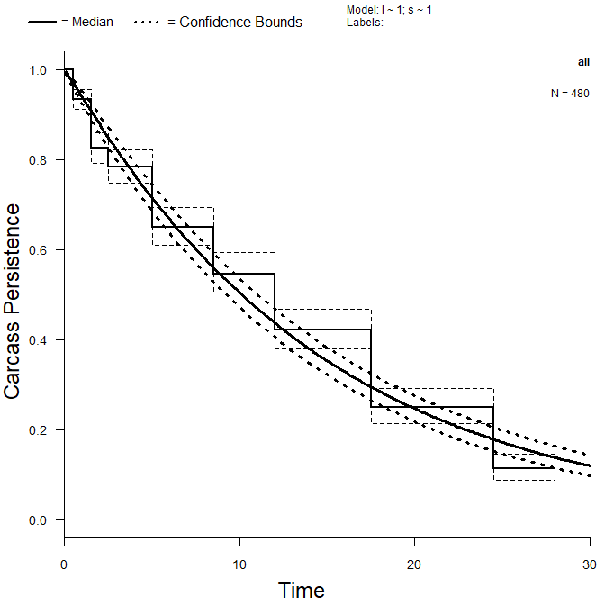

```r
plot(cpModel)
```

to visualize the model’s output.

```r
rcp(n = 10, cpModel)
```

```
#> $all
#>              l         s
#>  [1,] 2.719931 1.0124029
#>  [2,] 2.627515 0.9826370
#>  [3,] 2.679710 0.9010054
#>  [4,] 2.716126 0.8877428
#>  [5,] 2.606494 1.0168743
#>  [6,] 2.644940 0.9635792
#>  [7,] 2.598025 0.9163579
#>  [8,] 2.687417 0.9618728
#>  [9,] 2.646844 0.9172422
#> [10,] 2.609627 1.0595105
```

```r
rcp(n = 10, cpModel, type = "ppersist")
```

```
#> $all
#>             pda      pdb
#>  [1,] 0.9960318 14.17332
#>  [2,] 1.0007619 14.94753
#>  [3,] 1.0902556 14.71550
#>  [4,] 0.9943489 13.71914
#>  [5,] 1.0024874 13.53621
#>  [6,] 1.0460542 14.09745
#>  [7,] 1.0373792 13.91688
#>  [8,] 1.0142029 15.03153
#>  [9,] 0.9924402 14.23189
#> [10,] 1.0375286 15.62960
```

You can complicate the `l` and `s` formulae independently

```r
cpm(formula_l = l ~ Visibility*GroundCover, formula_s = s ~ 1, data = dataCP,
  left = "LastPresentDecimalDays", right = "FirstAbsentDecimalDays",
  dist = "weibull"
)
```

```
#> $call
#> cpm(formula_l = l ~ Visibility * GroundCover, formula_s = s ~
#>     1, data = dataCP, left = "LastPresentDecimalDays", right = "FirstAbsentDecimalDays",
#>     dist = "weibull")
#>
#> $formula_l
#> l ~ Visibility * GroundCover
#>
#> $formula_s
#> s ~ 1
#>
#> $distribution
#> [1] "weibull"
#>
#> $predictors
#> [1] "Visibility"  "GroundCover"
#>
#> $AICc
#> [1] 2107.064
#>
#> $convergence
#> [1] 0
#>
#> $cellwiseTable_ls
#>   cell l_median l_lower l_upper s_median s_lower s_upper
#> 1  H.A  2.64624 2.45578 2.83669  0.96768 0.89912 1.03624
#> 2  L.A  2.61629 2.42451 2.80808  0.96768 0.89912 1.03624
#> 3  M.A  2.53458 2.34753 2.72164  0.96768 0.89912 1.03624
#> 4  H.B  2.78824 2.59550 2.98099  0.96768 0.89912 1.03624
#> 5  L.B  2.71035 2.52022 2.90048  0.96768 0.89912 1.03624
#> 6  M.B  2.71520 2.52514 2.90525  0.96768 0.89912 1.03624
#>
#> $cellwiseTable_ab
#>   cell pda_median pda_lower pda_upper pdb_median pdb_lower pdb_upper
#> 1  H.A     1.0334    1.1122   0.96503   14.10092  11.65552  17.05921
#> 2  L.A     1.0334    1.1122   0.96503   13.68486  11.29669  16.57806
#> 3  M.A     1.0334    1.1122   0.96503   12.61113  10.45970  15.20524
#> 4  H.B     1.0334    1.1122   0.96503   16.25239  13.40329  19.70732
#> 5  L.B     1.0334    1.1122   0.96503   15.03454  12.43133  18.18287
#> 6  M.B     1.0334    1.1122   0.96503   15.10763  12.49264  18.26981
```

Given that the exponential only has one parameter (`l`, location), a model for scale (`formula_s`) is not required:

```r
cpModExp <- cpm(formula_l = l ~ Visibility*GroundCover, data = dataCP,
              left = "LastPresentDecimalDays",
              right = "FirstAbsentDecimalDays", dist = "exponential"
            )
```

### Set of Carcass Persistence Models

The function `cpmSet` provides a simple wrapper on `cpm` that facilitates analyzing a set of `cpm` models defined as all allowable models simpler than, and including, the provided model formulae (where “allowable” means that any interaction terms have all component terms included in the model).

In addition, `cpmSet` includes the four base distributions (exponential, weibull, lognormal, loglogistic) and crosses them with the predictor models, but this can be restricted using the `dist` argument.

Consider the following model set analysis, where visibility and season are included in the `l` formula but only visibility is in the `s` formula, and all only the exponential and lognormal distributions are included, which generates a set of 15 models:

```r
cpmModSet <- cpmSet(formula_l = l ~ Visibility*Season,
               formula_s = s ~ Visibility, data = dataCP,
               left = "LastPresentDecimalDays",
               right = "FirstAbsentDecimalDays",
               dist = c("exponential", "lognormal")
             )
names(cpmModSet)
```

```
#>  [1] "dist: exponential; l ~ Visibility * Season; NULL"
#>  [2] "dist: exponential; l ~ Visibility + Season; NULL"
#>  [3] "dist: exponential; l ~ Season; NULL"
#>  [4] "dist: exponential; l ~ Visibility; NULL"
#>  [5] "dist: exponential; l ~ 1; NULL"
#>  [6] "dist: lognormal; l ~ Visibility * Season; s ~ Visibility"
#>  [7] "dist: lognormal; l ~ Visibility + Season; s ~ Visibility"
#>  [8] "dist: lognormal; l ~ Season; s ~ Visibility"
#>  [9] "dist: lognormal; l ~ Visibility; s ~ Visibility"
#> [10] "dist: lognormal; l ~ 1; s ~ Visibility"
#> [11] "dist: lognormal; l ~ Visibility * Season; s ~ 1"
#> [12] "dist: lognormal; l ~ Visibility + Season; s ~ 1"
#> [13] "dist: lognormal; l ~ Season; s ~ 1"
#> [14] "dist: lognormal; l ~ Visibility; s ~ 1"
#> [15] "dist: lognormal; l ~ 1; s ~ 1"
```

The resulting model outputs can be compared in an AICc table

```r
cpmSetAICcTab(cpmModSet)
```

```
#>           dist               l formula      s formula     AICc Delta AICc
#> 5  exponential                   l ~ 1           NULL 2098.271      0.000
#> 3  exponential              l ~ Season           NULL 2098.625      0.354
#> 4  exponential          l ~ Visibility           NULL 2101.705      3.434
#> 2  exponential l ~ Visibility + Season           NULL 2102.021      3.750
#> 1  exponential l ~ Visibility * Season           NULL 2105.719      7.448
#> 15   lognormal                   l ~ 1          s ~ 1 2158.031     59.760
#> 13   lognormal              l ~ Season          s ~ 1 2159.588     61.317
#> 10   lognormal                   l ~ 1 s ~ Visibility 2160.863     62.592
#> 14   lognormal          l ~ Visibility          s ~ 1 2161.984     63.713
#> 8    lognormal              l ~ Season s ~ Visibility 2162.396     64.125
#> 12   lognormal l ~ Visibility + Season          s ~ 1 2163.556     65.285
#> 9    lognormal          l ~ Visibility s ~ Visibility 2164.840     66.569
#> 11   lognormal l ~ Visibility * Season          s ~ 1 2165.754     67.483
#> 7    lognormal l ~ Visibility + Season s ~ Visibility 2166.388     68.117
#> 6    lognormal l ~ Visibility * Season s ~ Visibility 2168.541     70.270
```

The `plot` function is defined for the `cpmSet` class, and by default, creates a new plot window on command for each sub-model. If we want to only plot a specific single (or subset) of models from the full set, we can utilize the `specificModel` argument:

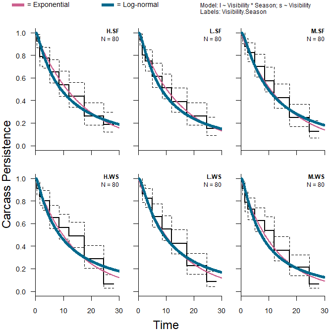

```r
plot(cpmModSet,
  specificModel = "dist: lognormal; l ~ Visibility * Season; s ~ Visibility")
```

### Multiple Sizes of Animals and Sets of Carcass Persistence Models

Often, carcasses are grouped in multiple size classes, and we are interested in analyzing a set of models separately for each size class. To do so, we use the `cpmSetSize` function, which is a wrapper on `cpmSet` that runs the subfunction for each unique size class in the column identified by the `sizeclassCol` argument:

```r
cpmModSetSize <- cpmSetSize(formula_l = l ~ Visibility*Season,
                   formula_s = s ~ Visibility, data = dataCP,
                   left = "LastPresentDecimalDays",
                   right = "FirstAbsentDecimalDays",
                   dist = c("exponential", "lognormal"),
                   sizeclassCol = "Size"
                 )
```

The output from `cpmSetSize` is a list where each element corresponds to a different unique size class, and contains the associated `cpmSet`object, which itself is a list of `cpm` outputs:

```r
names(cpmModSetSize)
```

```
#> [1] "S"  "L"  "M"  "XL"
```

```r
names(cpmModSetSize[[1]])
```

```
#>  [1] "dist: exponential; l ~ Visibility * Season; NULL"
#>  [2] "dist: exponential; l ~ Visibility + Season; NULL"
#>  [3] "dist: exponential; l ~ Season; NULL"
#>  [4] "dist: exponential; l ~ Visibility; NULL"
#>  [5] "dist: exponential; l ~ 1; NULL"
#>  [6] "dist: lognormal; l ~ Visibility * Season; s ~ Visibility"
#>  [7] "dist: lognormal; l ~ Visibility + Season; s ~ Visibility"
#>  [8] "dist: lognormal; l ~ Season; s ~ Visibility"
#>  [9] "dist: lognormal; l ~ Visibility; s ~ Visibility"
#> [10] "dist: lognormal; l ~ 1; s ~ Visibility"
#> [11] "dist: lognormal; l ~ Visibility * Season; s ~ 1"
#> [12] "dist: lognormal; l ~ Visibility + Season; s ~ 1"
#> [13] "dist: lognormal; l ~ Season; s ~ 1"
#> [14] "dist: lognormal; l ~ Visibility; s ~ 1"
#> [15] "dist: lognormal; l ~ 1; s ~ 1"
```